# pcos-analysis-report

# 5. Research Question 2: Are Irregular Periods Associated With Higher PCOS Risk?

Since both variables are categorical, we conduct a chi-square test of independence.

### 5.1 Creating a contingency table

```r
table(pcos_df$pcos, pcos_df$cycle)
```

```
##
##       Irregular Regular
##   No         56     307
##   Yes        94      82
```

The chi-square test assumes that all expected counts are ≥ 5, which we confirm is met in this dataset.

### 5.2 Chi-Square Test

```r
chisq.test(pcos_df$pcos, pcos_df$cycle)
```

```
##
##  Pearson's Chi-squared test with Yates' continuity correction
##
## data:  pcos_df$pcos and pcos_df$cycle
## X-squared = 83.258, df = 1, p-value < 2.2e-16
```

### 5.3 Visualising the Association

We create a bar graph to illustrate the proportion of regular vs. irregular menstrual cycles by PCOS status:

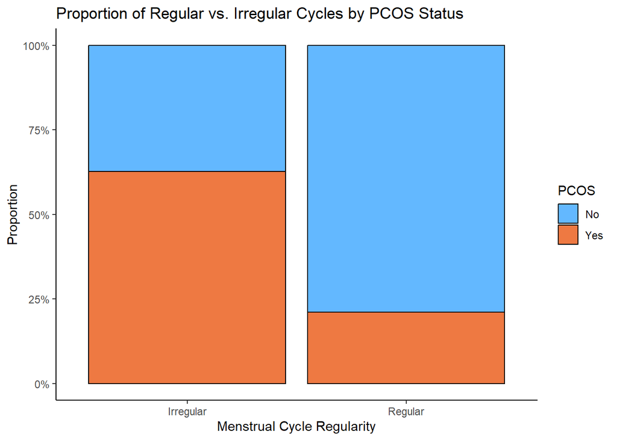

```r
ggplot(pcos_df, aes(x = cycle, fill = pcos)) +
  geom_bar(position = "fill", color = "black") +
  labs(x = "Menstrual Cycle Regularity", y = "Proportion", fill = "PCOS",
       title = "Proportion of Regular vs. Irregular Cycles by PCOS Status") +
  scale_y_continuous(labels = scales::percent) +
  scale_fill_manual(values = c("No" = "steelblue1", "Yes" = "sienna2"))
```

### 5.4 Conclusion

- The majority of women with irregular menstrual cycles have PCOS.
- Most women with regular cycles do not have PCOS, though a small proportion still do.

This analysis confirms a strong association between menstrual cycle irregularity and increased PCOS risk.

# 6. Research Question 3 : Do Hormone Levels Differ Between PCOS and Non-PCOS Women?

### 6.1 Checking Normality of Hormone Levels

We first assess whether hormone levels follow a normal distribution using the Shapiro-Wilk test:

```r
hormones <- c("fsh", "lh", "fsh_lh_ratio", "tsh", "amh", "prl", "prg")

for (hormone in hormones) {
  print(hormone)
  print(shapiro.test(pcos_df[[hormone]]))
}
```

```
## [1] "fsh"
##
##  Shapiro-Wilk normality test
##
## data:  pcos_df[[hormone]]
## W = 0.02379, p-value < 2.2e-16
##
## [1] "lh"
##
##  Shapiro-Wilk normality test
##
## data:  pcos_df[[hormone]]
## W = 0.027288, p-value < 2.2e-16
##
## [1] "fsh_lh_ratio"
##
##  Shapiro-Wilk normality test
##
## data:  pcos_df[[hormone]]
## W = 0.049997, p-value < 2.2e-16
##
## [1] "tsh"
##
##  Shapiro-Wilk normality test
##
## data:  pcos_df[[hormone]]
## W = 0.4139, p-value < 2.2e-16
##
## [1] "amh"
##
##  Shapiro-Wilk normality test
##
## data:  pcos_df[[hormone]]
## W = 0.72465, p-value < 2.2e-16
##
## [1] "prl"
##
##  Shapiro-Wilk normality test
##
## data:  pcos_df[[hormone]]
## W = 0.82024, p-value < 2.2e-16
##
## [1] "prg"
##
##  Shapiro-Wilk normality test
##
## data:  pcos_df[[hormone]]
## W = 0.051056, p-value < 2.2e-16
```

The results show that all p-values are < 0.05, indicating that none of the hormone levels are normally distributed. Since normality assumptions are violated, we proceed with a non-parametric test.

### 6.2 Comparing Hormone Levels Using the Mann-Whitney U Test

We use the Mann-Whitney U test (Wilcoxon rank-sum test) to compare hormone levels between women with and without PCOS:

```r
# non-parametric test - the mann whitney u test
wilcoxon_results <- lapply(hormones, function(hormone) {
  test <- wilcox.test(pcos_df[[hormone]] ~ pcos_df$pcos)
  return(data.frame(Hormone = hormone, W = test$statistic, p_value = test$p.value))
})

wilcoxon_results_df <- do.call(rbind, wilcoxon_results)
print(wilcoxon_results_df)
```

```
##         Hormone       W      p_value
## W           fsh 36416.5 8.352508e-03
## W1           lh 30311.5 3.357906e-01
## W2 fsh_lh_ratio 36630.5 5.715480e-03
## W3          tsh 31092.5 6.157303e-01
## W4          amh 22684.5 4.739950e-08
## W5          prl 31053.5 5.996543e-01
## W6          prg 33295.0 4.181215e-01
```

The results indicate that FSH, FSH/LH ratio, and AMH show significant differences between groups, while LH, TSH, PRL, and PRG do not.

### 6.3 Effect Size: Cliff’s Delta

To assess the magnitude of these differences, we compute Cliff’s delta for the significant hormones:

```r
significant_hormones <- c("fsh", "fsh_lh_ratio", "amh")


# effect size cliffs delta
cliff.delta(pcos_df$fsh ~ pcos_df$pcos)
```

```
##
## Cliff's Delta
##
## delta estimate: 0.1400106 (negligible)
## 95 percent confidence interval:
##      lower      upper
## 0.03874955 0.23842536
```

```r
cliff.delta(pcos_df$fsh_lh_ratio ~ pcos_df$pcos)
```

```
##
## Cliff's Delta
##
## delta estimate: 0.1467099 (negligible)
## 95 percent confidence interval:
##      lower      upper
## 0.03925573 0.25080963
```

```r
cliff.delta(pcos_df$amh ~ pcos_df$pcos)
```

```
##
## Cliff's Delta
##
## delta estimate: -0.2898666 (small)
## 95 percent confidence interval:
##      lower      upper
## -0.3916938 -0.1810248
```

The results suggest weak effect sizes, indicating that while the differences are statistically significant, they may not be clinically meaningful.

### 6.4 Visualizing Hormone Level Differences

Since hormone levels are in separate columns, we reshape the dataset for visualization:

```r
# reshaping the data for ggplot
pcos_long <- reshape2::melt(pcos_df, id.vars = "pcos", measure.vars = significant_hormones)
head(pcos_long)
```

```
##   pcos variable value
## 1   No      fsh  7.95
## 2   No      fsh  6.73
## 3  Yes      fsh  5.54
## 4   No      fsh  8.06
## 5   No      fsh  3.98
## 6   No      fsh  3.24
```

We then create boxplots to compare hormone levels between groups:

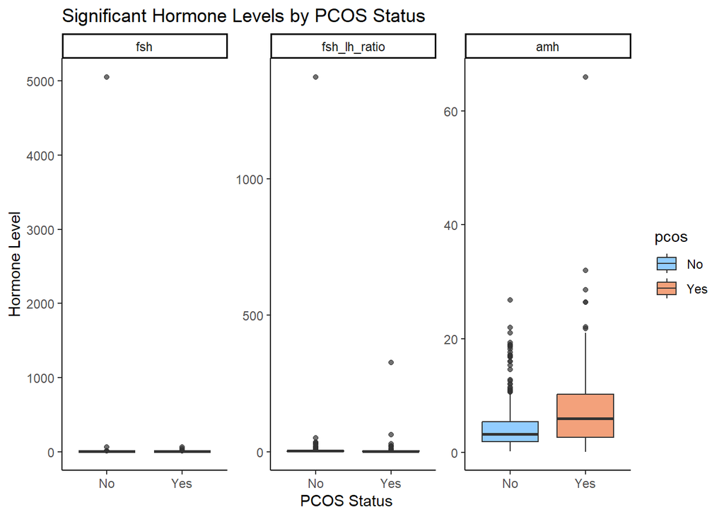

```r
# boxplot
ggplot(pcos_long, aes(x = pcos, y = value, fill = pcos)) +
  geom_boxplot(alpha = 0.7) +
  facet_wrap(~variable, scales = "free") +
  labs(title = "Significant Hormone Levels by PCOS Status",
       x = "PCOS Status", y = "Hormone Level") +
  scale_fill_manual(values = c("No" = "steelblue1", "Yes" = "sienna2"))
```

The boxplots reveal extreme outliers. The presence of extreme outliers is disproportionately stretching the y-axis, causing the boxplots to appear highly compressed. This makes it difficult to visually assess the distribution of hormone levels across groups. Therefore, we remove the outliers for clearer visualization and more reliable interpretation.

### 6.5 Removing Outliers

We define a function to remove values beyond 1.5 times the interquartile range (IQR):

```r
# function for removing outliers
remove_outliers <- function(x) {
  q1 <- quantile(x, 0.25, na.rm = TRUE)
  q3 <- quantile(x, 0.75, na.rm = TRUE)
  iqr <- q3 - q1
  x[x > (q3 + 1.5 * iqr)] <- NA  # Remove extreme values
  x[x < (q1 - 1.5 * iqr)] <- NA
  return(x)
}
```

We apply this function to the significant hormones:

```r
# applying that function to our significant hormones
pcos_df$filtered_fsh <- remove_outliers(pcos_df$fsh)
pcos_df$filtered_fsh_lh_ratio <- remove_outliers(pcos_df$fsh_lh_ratio)
pcos_df$filtered_amh <- remove_outliers(pcos_df$amh)

glimpse(pcos_df)
```

```
## Rows: 539
## Columns: 16
## $ pcos                  <fct> No, No, Yes, No, No, No, No, No, No, No, No, No,…
## $ age                   <dbl> 28, 36, 33, 37, 25, 36, 34, 33, 32, 36, 20, 26, …
## $ weight                <dbl> 44.6, 65.0, 68.8, 65.0, 52.0, 74.1, 64.0, 58.5, …
## $ height                <dbl> 152.0, 161.5, 165.0, 148.0, 161.0, 165.0, 156.0,…
## $ bmi                   <dbl> 19.30000, 24.92116, 25.27089, 29.67495, 20.06095…
## $ cycle                 <fct> Regular, Regular, Regular, Regular, Regular, Reg…
## $ fsh                   <dbl> 7.95, 6.73, 5.54, 8.06, 3.98, 3.24, 2.85, 4.86, …
## $ lh                    <dbl> 3.68, 1.09, 0.88, 2.36, 0.90, 1.07, 0.31, 3.07, …
## $ fsh_lh_ratio          <dbl> 2.160326, 6.174312, 6.295455, 3.415254, 4.422222…
## $ tsh                   <dbl> 0.68, 3.16, 2.54, 16.41, 3.57, 1.60, 1.51, 12.18…
## $ amh                   <dbl> 2.07, 1.53, 6.63, 1.22, 2.26, 6.74, 3.05, 1.54, …
## $ prl                   <dbl> 45.16, 20.09, 10.52, 36.90, 30.09, 16.18, 26.41,…
## $ prg                   <dbl> 0.57, 0.97, 0.36, 0.36, 0.38, 0.30, 0.46, 0.26, …
## $ filtered_fsh          <dbl> 7.95, 6.73, 5.54, 8.06, 3.98, 3.24, 2.85, 4.86, …
## $ filtered_fsh_lh_ratio <dbl> 2.160326, 6.174312, 6.295455, 3.415254, 4.422222…
## $ filtered_amh          <dbl> 2.07, 1.53, 6.63, 1.22, 2.26, 6.74, 3.05, 1.54, …
```

We reshape the data again:

```r
pcos_long_reshape <- reshape2::melt(pcos_df, id.vars = "pcos",
                            measure.vars = c("filtered_fsh", "filtered_fsh_lh_ratio", "filtered_amh"))

head(pcos_long_reshape)
```

```
##   pcos     variable value
## 1   No filtered_fsh  7.95
## 2   No filtered_fsh  6.73
## 3  Yes filtered_fsh  5.54
## 4   No filtered_fsh  8.06
## 5   No filtered_fsh  3.98
## 6   No filtered_fsh  3.24
```

### 6.6 Reassessing the Wilcoxon Test and Effect Sizes

We verify whether the results remain consistent after removing outliers:

```r
# just making sure results of the wilcoxon are similar..
wilcox.test(pcos_df$filtered_fsh ~ pcos_df$pcos)
```

```
##
##  Wilcoxon rank sum test with continuity correction
##
## data:  pcos_df$filtered_fsh by pcos_df$pcos
## W = 35029, p-value = 0.006066
## alternative hypothesis: true location shift is not equal to 0
```

```r
wilcox.test(pcos_df$filtered_fsh_lh_ratio ~ pcos_df$pcos)
```

```
##
##  Wilcoxon rank sum test with continuity correction
##
## data:  pcos_df$filtered_fsh_lh_ratio by pcos_df$pcos
## W = 30714, p-value = 0.01023
## alternative hypothesis: true location shift is not equal to 0
```

```r
wilcox.test(pcos_df$filtered_amh ~ pcos_df$pcos)
```

```
##
##  Wilcoxon rank sum test with continuity correction
##
## data:  pcos_df$filtered_amh by pcos_df$pcos
## W = 19375, p-value = 0.0001352
## alternative hypothesis: true location shift is not equal to 0
```

The tests remain statistically significant (p-values < 0.05).

We also check Cliff’s delta again:

```r
cliff.delta(pcos_df$filtered_fsh ~ pcos_df$pcos)
```

```
##
## Cliff's Delta
##
## delta estimate: 0.1473469 (small)
## 95 percent confidence interval:
##      lower      upper
## 0.04653326 0.24518917
```

```r
cliff.delta(pcos_df$filtered_fsh_lh_ratio ~ pcos_df$pcos)
```

```
##
## Cliff's Delta
##
## delta estimate: 0.1419542 (negligible)
## 95 percent confidence interval:
##      lower      upper
## 0.03026959 0.25013794
```

```r
cliff.delta(pcos_df$filtered_amh ~ pcos_df$pcos)
```

```
##
## Cliff's Delta
##
## delta estimate: -0.2186126 (small)
## 95 percent confidence interval:
##       lower       upper
## -0.33326922 -0.09758426
```

After removing extreme outliers, the effect size for FSH increased from negligible to small. However, the overall effect sizes remain small, indicating that while the differences are statistically significant, their practical significance may be minimal.

### 6.7 Final Visualization (Outliers Removed)

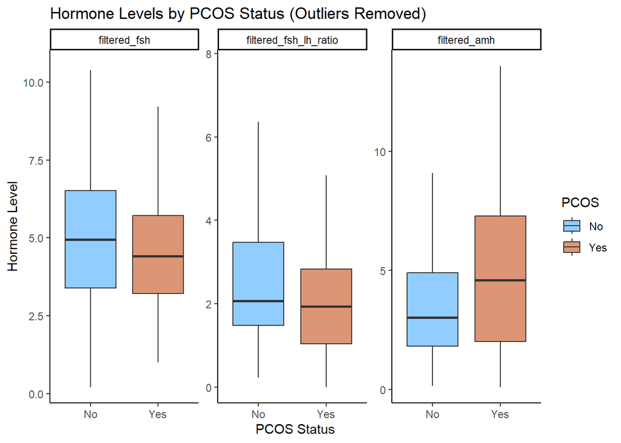

```r
ggplot(pcos_long_reshape, aes(x = pcos, y = value, fill = pcos)) +
  geom_boxplot(alpha = 0.7, outlier.shape = NA) +  # Hide outliers
  facet_wrap(~variable, scales = "free") +
  labs(title = "Hormone Levels by PCOS Status (Outliers Removed)",
       x = "PCOS Status", y = "Hormone Level", fill = "PCOS") +
  scale_fill_manual(values = c("No" = "steelblue1", "Yes" = "sienna3"))
```

### 6.8 Conclusion

FSH is lower in women with PCOS compared to those without PCOS.

FSH/LH ratio is lower in women with PCOS.

AMH is higher in women with PCOS.

However small-to-negligible effect sizes suggest that these differences may have limited clinical relevance.

# 7. Discussion & Conclusions

From the statistical tests conducted, it may be concluded that:

BMI is significantly higher in PCOS individuals (p < 0.05), however the effect size is small to moderate. Higher BMI in PCOS patients is consistent with established research.<sup>6</sup> Studies indicate that women with PCOS have a greater risk of overweight, obesity, and central obesity, emphasizing the importance of weight management as part of clinical treatment.<sup>7</sup> Furthermore, BMI management in PCOS patients enhances glucose metabolism, thus decreasing the risk for developing gestational diabetes during pregnancy.<sup>8</sup>

However, it should be noted that PCOS cases in which the patient’s BMI is within the normal range is also prevalent (although lower) in clinical practice.<sup>9</sup>

Irregular periods are strongly associated with PCOS (p < 0.001). It was found that 75-85% of women with PCOS experience oligomenorrhea (infrequent periods) or amenorrhea (absent periods).<sup>10</sup>

According to existing literature, this irregularity is mainly due to excess androgen levels, which disrupt normal ovulation. This excess androgen interferes with ovulation, preventing eggs from developing and being regularly released from follicles.<sup>11</sup>

In addition, PCOS is characterised by polycystic ovaries, where multiple small, fluid-filled follicles containing immature eggs accumulate along the ovarian edges. These ovaries may not function properly, further contributing to menstrual irregularities.<sup>12</sup>

Visualisation of the data also showed that not all PCOS cases have irregular cycles, which is also consistent with current statistics.<sup>13</sup>

Some hormone levels, including FSH, FSH/LH ratio, and AMH, significantly differed between groups. This is consistent with prior medical literature:

- FSH levels tend to be lower in PCOS individuals.<sup>14</sup>
- PCOS is typically associated with a low FSH and high LH, leading to a decreased FSH/LH ratio.<sup>15</sup>
- AMH levels are higher in PCOS women, as they have a greater number of antral follicles.<sup>16</sup>

Despite the statistical significance, however, the effect sizes were small, suggesting limited clinical impact. This aligns with research indicating that while hormonal differences are associated with PCOS, their variability within populations may reduce their effectiveness as standalone diagnostic markers.<sup>17</sup>

Interestingly, LH levels did not significantly differ between PCOS and non-PCOS individuals. This contrasts with prior research stating that PCOS involves altered gonadotropin regulation, leading to a relative increase in LH compared to FSH.<sup>18</sup> This could be explained by hormone fluctuations across the menstrual cycle, which were not accounted for in this dataset.

While this study provides meaningful insights, several limitations must be acknowledged. Firstly, the dataset was relatively small, with only 539 observations. Moreover, the data was only collected from hospitals in Kerala, India – thus introducing geographical bias. Hormone fluctuations across different phases of the menstrual cycle were also not accounted for in the dataset. Finally, PCOS is a heterogenous condition, and the dataset used may not fully capture all phenotypic variations.

In the future, research should analyze larger, more diverse datasets, incorporate additional clinical factors, such as insulin resistance and metabolic markers, to enhance PCOS classification, and investigate hormonal patterns across different menstrual phases for a better understanding.

# 8. Bibliography

1. National Center for Biotechnology Information. Polycystic Ovary Syndrome (PCOS). [Internet]. Available from: https://www.ncbi.nlm.nih.gov/books/NBK459251/
2. Dennett CC, Simon J. The role of polycystic ovary syndrome in reproductive and metabolic health: overview and approaches for treatment. Diabetes Spectr. 2015 May;28(2):116-20. doi: 10.2337/diaspect.28.2.116. PMID: 25987810; PMCID: PMC4433074.
3. The Medical Journal of Australia. Australian-led PCOS guideline an international first. [Internet]. 2018. Available from: https://www.mja.com.au/journal/2018/australian-led-pcos-guideline-international-first
4. Gibson-Helm M, Teede H, Dunaif A, Dokras A. Delayed diagnosis and a lack of information associated with dissatisfaction in women with polycystic ovary syndrome. J Clin Endocrinol Metab. 2017 Feb 1;102(2):604-612. doi: 10.1210/jc.2016-2963. PMID: 27906550; PMCID: PMC6283441.
5. Kottarathil P. Polycystic ovary syndrome (PCOS) [dataset]. Kaggle. 2020. Available from: https://www.kaggle.com/prasoonkottarathil/polycystic-ovary-syndrome-pcos
6. Barber TM, McCarthy MI, Wass JA, Franks S. Obesity and polycystic ovary syndrome: implications for pathogenesis and treatment. J Clin Endocrinol Metab. 2006;91(1):7-13. PMCID: PMC2744370. Available from: https://pmc.ncbi.nlm.nih.gov/articles/PMC2744370/
7. Lim SS, Davies MJ, Norman RJ, Moran LJ. Overweight, obesity and central obesity in women with polycystic ovary syndrome: a systematic review and meta-analysis. Hum Reprod Update. 2012;18(6):618–637. doi: 10.1093/humupd/dms030.
8. Ma N, Zhou J, Lu W. The normal body mass index (BMI) of women with polycystic ovary syndrome (PCOS) was associated with IVF/ICSI assisted conception outcomes. Clin Exp Obstet Gynecol. 2023;50(11):228. doi: 10.31083/j.ceog5011228.
9. National Library of Medicine. PCOS and obesity. [Internet]. Available from: https://pmc.ncbi.nlm.nih.gov/articles/PMC10986768/
10. Harris HR, Babic A, Webb PM, Nagle CM, Jordan SJ, Risch HA, et al. Polycystic ovary syndrome, oligomenorrhea, and risk of ovarian cancer histotypes: Evidence from the Ovarian Cancer Association Consortium. Cancer Epidemiol Biomarkers Prev. 2018 Feb;27(2):174-182. doi: 10.1158/1055-9965.EPI-17-0655. PMID: 29141849; PMCID: PMC5877463.
11. Cleveland Clinic. Polycystic ovary syndrome (PCOS). [Internet]. Available from: https://my.clevelandclinic.org/health/diseases/8316-polycystic-ovary-syndrome-pcos
12. Mayo Clinic. Polycystic ovary syndrome (PCOS) - Symptoms & causes. 2023. Available from: https://www.mayoclinic.org/diseases-conditions/pcos/symptoms-causes/syc-20353439
13. Carmina E, Lobo RA. Do hyperandrogenic women with normal menses have polycystic ovary syndrome? Fertil Steril. 1999 Feb;71(2):319-22. doi: 10.1016/s0015-0282(98)00455-5. PMID: 9988405.
14. Emanuel RHK, Roberts J, Docherty PD, Lunt H, Campbell RE, Möller K. A review of the hormones involved in the endocrine dysfunctions of polycystic ovary syndrome and their interactions. Front Endocrinol (Lausanne). 2022 Nov 15;13:1017468. doi: 10.3389/fendo.2022.1017468. PMID: 36457554; PMCID: PMC9705998.
15. Emanuel RHK, Roberts J, Docherty PD, Lunt H, Campbell RE, Möller K. A review of the hormones involved in the endocrine dysfunctions of polycystic ovary syndrome and their interactions. Front Endocrinol (Lausanne). 2022 Nov 15;13:1017468. doi: 10.3389/fendo.2022.1017468. PMID: 36457554; PMCID: PMC9705998.
16. National Library of Medicine. Anti-Müllerian hormone and PCOS. [Internet]. Available from: https://pmc.ncbi.nlm.nih.gov/articles/PMC8006968/
17. Skiba MA, Islam RM, Bell RJ, Davis SR. Understanding variation in prevalence estimates of polycystic ovary syndrome: A systematic review and meta-analysis. Hum Reprod Update. 2018;24(6):694–709. doi: 10.1093/humupd/dmy022.
18. Taylor AE, McCourt B, Martin KA, Anderson EJ, Adams JM, Schoenfeld D, Hall JE. Determinants of abnormal gonadotropin secretion in clinically defined women with polycystic ovary syndrome. J Clin Endocrinol Metab. 1997 Jul;82(7):2248-56. doi: 10.1210/jcem.82.7.4105. PMID: 9215302.